# Lab_6f

### Team Members: Aitor Gonzalez (49092725), Palmer Nelson (47066829), Abdul Wasay (49121481)

## Preparation (3 points total)

### [1.5 points]

Choose and explain what metric(s) you will use to evaluate your algorithm’s performance. You should give a detailed argument for why this (these) metric(s) are appropriate on your data. That is, why is the metric appropriate for the task (e.g., in terms of the business case for the task). Please note: rarely is accuracy the best evaluation metric to use. Think deeply about an appropriate measure of performance.

Source: https://www.kaggle.com/datasets/gpiosenka/cards-image-datasetclassification We chose the playing cards dataset. The main use case is so that someone who is visually impaired can use this model to play with a regular deck of cards. Brail marked cards exist, but are not widely avialble. And deploying this model in a discrete app that plays the card name in the headphones of the user, can make the game playable for someone that is visually impaired.

### [1.5 points]

Choose the method you will use for dividing your data into training and testing (i.e., are you using Stratified 10-fold cross validation? Shuffle splits? Why?). Explain why your chosen method is appropriate or use more than one method as appropriate. Convince me that your cross validation method is a realistic mirroring of how an algorithm would be used in practice. appropriate measure of performance.

In this particular use case, we are using a dataset that is pre-divided. The reasons for choosing to use the provided split is:

1. This ensures that we are minimizing leakage that may be introduced if we split ourselves
2. Given the high rating of the dataset on kaggle, we assume there it also has a good balance in the split for train and test with good spread of each of the classes.
3. Using pre-split data helps us reduce errors on our end and saves us time in the process.

```python
import tensorflow as tf
import tensorflow.keras as keras
from tensorflow.keras.models import Sequential
from tensorflow.keras.layers import Reshape, Input
from tensorflow.keras.layers import Dense, Dropout, Activation, Flatten
from tensorflow.keras.layers import Conv2D, MaxPooling2D
from tensorflow.keras.utils import plot_model
from tensorflow.keras.preprocessing.image import ImageDataGenerator
from tensorflow.keras.layers import RandomFlip, RandomRotation, RandomTranslation
from tensorflow.keras.layers import RandomContrast, RandomBrightness, RandomZoom
from tensorflow.keras.callbacks import EarlyStopping
from tensorflow.keras.regularizers import l2
from tensorflow.keras.layers import Input, average, concatenate
from tensorflow.keras.models import Model
from tensorflow.keras.layers import BatchNormalization
from tensorflow.keras.optimizers.legacy import Adam
import os
import struct
import numpy as np
import matplotlib.pyplot as plt
from ipywidgets import widgets, Layout, Button, Box, VBox, Label
```

```python
import warnings
warnings.filterwarnings('ignore')  # Ignore all warnings
```

```python
tf.config.list_physical_devices('GPU')
```

```
[PhysicalDevice(name='/physical_device:GPU:0', device_type='GPU')]
```

```python
print("Num GPUs Available: ", len(tf.config.list_physical_devices('GPU')))
```

```
Num GPUs Available:  1
```

## Modeling (6 points total)

### [1.5 points]

Setup the training to use data expansion in Keras (also called data augmentation). Explain why the chosen data expansion techniques are appropriate for your dataset. You should make use of Keras augmentation layers, like in the class examples.

```python
pixels = 128
train_ds    = tf.keras.utils.image_dataset_from_directory("cards/train",batch_size=32,image_size=(pixels,pixels),seed=0)
test_ds     = tf.keras.utils.image_dataset_from_directory("cards/test", batch_size=32,image_size=(pixels,pixels),seed=0)
valid_ds    = tf.keras.utils.image_dataset_from_directory("cards/valid",batch_size=32,image_size=(pixels,pixels),seed=0)
class_Names = train_ds.class_names
print(class_Names)
```

[output not shown]

[output not shown]

```python
for images, labels in train_ds.take(1):
    print(images.shape)
```

```
(32, 128, 128, 3)
```

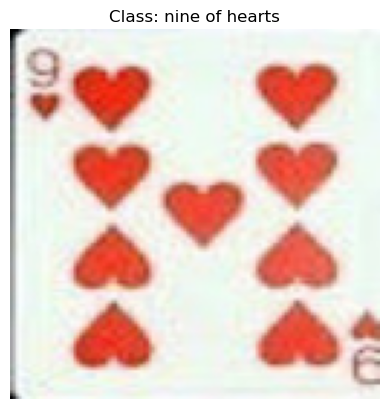

```python
import ipywidgets as widgets
import random

def display_random_image(dataset):
    # Randomly select a batch
    batch = next(iter(dataset))

    # Randomly select an image from the batch
    random_index = random.randint(0, len(batch[0]) - 1)
    image, label = batch[0][random_index], batch[1][random_index]

    # Display the image
    plt.imshow(image.numpy().astype("uint8"))
    plt.title("Class: " + str(dataset.class_names[label]))
    plt.axis('off')
    plt.show()

# Create a button widget
button = widgets.Button(description="Show Random Image")

# Display the button and the first random image
display_random_image(train_ds)  # Display an image initially
```

```python
def count_images_per_class(dataset, class_names):
    class_counts = {name: 0 for name in class_names}
    for images, labels in dataset:
        for label in labels:
            class_name = class_names[label]
            class_counts[class_name] += 1
    return class_counts

# Count and display the number of images per class
train_class_counts = count_images_per_class(train_ds, class_Names)
print("Number of images per class in training dataset:")
for class_name, count in train_class_counts.items():
    print(f"{class_name}: {count}")
```

```
Number of images per class in training dataset:
ace of clubs: 120
ace of diamonds: 129
ace of hearts: 171
ace of spades: 181
eight of clubs: 138
eight of diamonds: 159
eight of hearts: 152
eight of spades: 135
five of clubs: 150
five of diamonds: 138
five of hearts: 136
five of spades: 158
four of clubs: 157
four of diamonds: 114
four of hearts: 154
four of spades: 140
jack of clubs: 171
jack of diamonds: 160
jack of hearts: 168
jack of spades: 172
joker: 115
king of clubs: 128
king of diamonds: 135
king of hearts: 125
king of spades: 151
nine of clubs: 124
nine of diamonds: 129
nine of hearts: 133
nine of spades: 154
queen of clubs: 161
queen of diamonds: 163
queen of hearts: 139
queen of spades: 162
seven of clubs: 108
seven of diamonds: 124
seven of hearts: 143
seven of spades: 165
six of clubs: 152
six of diamonds: 139
six of hearts: 127
six of spades: 158
ten of clubs: 141
ten of diamonds: 151
ten of hearts: 129
ten of spades: 158
three of clubs: 126
three of diamonds: 153
three of hearts: 113
three of spades: 142
two of clubs: 130
two of diamonds: 133
two of hearts: 155
two of spades: 155
```

#### Because each of the classes have roughly the same number of images, we do not need to balance the dataset

### We have applied a few augmentations to our images.

### Variability of cards positioning relative to capturing device

Cards can be placed or held in any orientation during gameplay.

### Variability of lighting conditions in different environments

```python
# cnn = Sequential()
# tf.keras.models.Sequential()
# # add in augmentations directly
# cnn.add( RandomFlip("vertical") ) # flip vertical
# cnn.add( RandomRotation(0.1)) # rotate by 5%
# cnn.add( RandomBrightness(factor=0.1, value_range=(0.0, 1.0))) # add some to the mean
# cnn.add( RandomContrast(0.1)) # add or decrease contrast
```

### [2 points]

Create a convolutional neural network to use on your data using Keras. Investigate at least two different convolutional network architectures and investigate changing one or more parameters of each architecture such as the number of filters. This means, at a minimum, you will train a total of four models (2 different architectures, with 2 parameters changed in each architecture). Use the method of train/test splitting and evaluation metric that you argued for at the beginning of the lab. Visualize the performance of the training and validation sets per iteration (use the "history" parameter of Keras). Be sure that models converge

```python
# Create the model
cnn = Sequential()

# # Simplified Data Augmentation
# cnn.add(RandomFlip("horizontal"))  # flip horizontally
# cnn.add(RandomRotation(0.05))       # rotate by 5%
# cnn.add( RandomBrightness(factor=0.05, value_range=(0.0, 1.0))) # add some to the mean
# cnn.add( RandomContrast(0.05)) # add or decrease contrast

# First Convolutional Layer (reduced filters)
cnn.add(Conv2D(128, (3, 3), activation='relu', input_shape=(pixels, pixels, 3)))

# First Pooling Layer
cnn.add(MaxPooling2D(2, 2))

# Second Convolutional Layer (reduced filters)
cnn.add(Conv2D(64, (3, 3), activation='relu'))

# Second Pooling Layer
cnn.add(MaxPooling2D(2, 2))

# Dropout for Regularization (simplified)
cnn.add(Dropout(0.5))

# Flatten the output
cnn.add(Flatten())

# Simplified Dense Layer
cnn.add(Dense(64, activation='relu'))

# Output Layer (remains the same)
cnn.add(Dense(len(class_Names), activation='softmax'))



learning_rate = 0.00015  # A lower learning rate
optimizer = tf.keras.optimizers.legacy.Adam(learning_rate=0.0001)
#(learning_rate=learning_rate, clipvalue=1.0)  # Adding gradient clipping

cnn.compile(optimizer=optimizer,
            loss='sparse_categorical_crossentropy',
            metrics=['accuracy'])
```

```python
history = cnn.fit(train_ds, validation_data=valid_ds, epochs=20)

cnn_1 = cnn
```

```
2023-11-28 00:56:21.262465: I tensorflow/core/grappler/optimizers/custom_graph_optimizer_registry.cc:117] Plugin optimizer for device_type GPU is enabled.
```

```python
print(cnn.summary())

test_loss, test_accuracy = cnn.evaluate(test_ds)
print(f"Test accuracy: {test_accuracy}")
```

```
Model: "sequential_5"
_________________________________________________________________
 Layer (type)                Output Shape              Param #
=================================================================
 conv2d_10 (Conv2D)          (None, 126, 126, 128)     3584

 max_pooling2d_10 (MaxPooli  (None, 63, 63, 128)       0
 ng2D)

 conv2d_11 (Conv2D)          (None, 61, 61, 64)        73792

 max_pooling2d_11 (MaxPooli  (None, 30, 30, 64)        0
 ng2D)

 dropout_5 (Dropout)         (None, 30, 30, 64)        0

 flatten_5 (Flatten)         (None, 57600)             0

 dense_10 (Dense)            (None, 64)                3686464

 dense_11 (Dense)            (None, 53)                3445

=================================================================
Total params: 3767285 (14.37 MB)
Trainable params: 3767285 (14.37 MB)
Non-trainable params: 0 (0.00 Byte)
_________________________________________________________________
None
Test accuracy: 0.31698113679885864
```

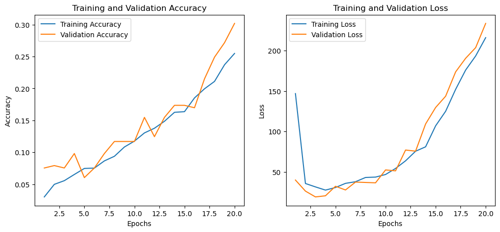

```python
# Extracting training and validation loss and accuracies
train_loss = history.history['loss']
train_accuracy = history.history['accuracy']
val_loss = history.history['val_loss']
val_accuracy = history.history['val_accuracy']

epochs = range(1, len(train_loss) + 1)

# Plot training and validation accuracy
plt.figure(figsize=(12, 5))
plt.subplot(1, 2, 1)
plt.plot(epochs, train_accuracy, label='Training Accuracy')
plt.plot(epochs, val_accuracy, label='Validation Accuracy')
plt.title('Training and Validation Accuracy')
plt.xlabel('Epochs')
plt.ylabel('Accuracy')
plt.legend()

# Plot training and validation loss
plt.subplot(1, 2, 2)
plt.plot(epochs, train_loss, label='Training Loss')
plt.plot(epochs, val_loss, label='Validation Loss')
plt.title('Training and Validation Loss')
plt.xlabel('Epochs')
plt.ylabel('Loss')
plt.legend()
```

```python
print(train_loss)
print(train_accuracy)
print(val_loss)
print(val_accuracy)
```

[output not shown]

```python
# Create the model
cnn = Sequential()

# # Simplified Data Augmentation
cnn.add(RandomFlip("horizontal"))  # flip horizontally
cnn.add(RandomRotation(0.01))       # rotate by 5%
cnn.add( RandomBrightness(factor=0.05, value_range=(0.0, 1.0))) # add some to the mean
cnn.add( RandomContrast(0.05)) # add or decrease contrast

# First Convolutional Layer (reduced filters)
cnn.add(Conv2D(16, (3, 3), activation='relu', input_shape=(pixels, pixels, 3)))

# First Pooling Layer
cnn.add(MaxPooling2D(2, 2))

# Second Convolutional Layer (reduced filters)
cnn.add(Conv2D(32, (3, 3), activation='relu'))

# Third Convolutional Layer (reduced filters)
cnn.add(Conv2D(32, (3, 3), activation='relu'))

# Second Pooling Layer
cnn.add(MaxPooling2D(2, 2))

# Dropout for Regularization (simplified)
cnn.add(Dropout(0.5))

# Flatten the output
cnn.add(Flatten())

# Simplified Dense Layer
cnn.add(Dense(64, activation='relu'))

# Output Layer (remains the same)
cnn.add(Dense(len(class_Names), activation='softmax'))

optimizer = tf.keras.optimizers.legacy.Adam(learning_rate=0.0001)

cnn.compile(optimizer=optimizer,
            loss='sparse_categorical_crossentropy',
            metrics=['accuracy'])
```

```python
history_2 = cnn.fit(train_ds, validation_data=valid_ds, epochs=20)

cnn_2 = cnn
```

[output not shown]

[output not shown]

[output not shown]

[output not shown]

[output not shown]

[output not shown]

[output not shown]

[output not shown]

[output not shown]

[output not shown]

[output not shown]

[output not shown]

[output not shown]

[output not shown]

[output not shown]

[output not shown]

[output not shown]

[output not shown]

[output not shown]

[output not shown]

[output not shown]

[output not shown]

[output not shown]

[output not shown]

[output not shown]

[output not shown]

[output not shown]

[output not shown]

[output not shown]

[output not shown]

[output not shown]

[output not shown]

[output not shown]

[output not shown]

[output not shown]

[output not shown]

[output not shown]

[output not shown]

[output not shown]

[output not shown]

[output not shown]

[output not shown]

[output not shown]

[output not shown]

[output not shown]

[output not shown]

[output not shown]

[output not shown]

[output not shown]

[output not shown]

[output not shown]

[output not shown]

[output not shown]

[output not shown]

[output not shown]

[output not shown]

[output not shown]

[output not shown]

[output not shown]

[output not shown]

[output not shown]

[output not shown]

[output not shown]

[output not shown]

[output not shown]

[output not shown]

[output not shown]

[output not shown]

[output not shown]

[output not shown]

[output not shown]

[output not shown]

[output not shown]

[output not shown]

[output not shown]

[output not shown]

[output not shown]

[output not shown]

[output not shown]

[output not shown]

[output not shown]

[output not shown]

[output not shown]

[output not shown]

[output not shown]

[output not shown]

[output not shown]

[output not shown]

[output not shown]

[output not shown]

[output not shown]

[output not shown]

[output not shown]

[output not shown]

[output not shown]

[output not shown]

[output not shown]

[output not shown]

[output not shown]

[output not shown]

[output not shown]

[output not shown]